# Analysis: How successful was LEAFF 2018?

[London East Asia Film Festival (LEAFF) 2018](https://www.leaff.org.uk/)

[Avision Ho](https://github.com/avisionh) and Chelsea Do Hyung Kim

2018-11-27

# Executive Summary

[figure not shown]

From the data analysed in this report, the key findings are:

**Survey respondents enjoyed LEAFF 2018 so much that 89% of them will return for future editions of LEAFF.**

**Survey respondents enjoyed LEAFF 2018 so much that 99% of them will recommend a friend or colleague to attend LEAFF.**

**Most survey respondents answered that they have watched or expect to watch 1-3 films during LEAFF 2018 as they may have other reasons for not attending more screenings, such as work or studies.**

**The top three reasons for why survey respondents wanted to attend LEAFF were *The film (40%), The director(s) and/or actor(s) (16%) and The subject/theme (15%)*.**

**60% of survey respondents said this is their first time coming to the festival, showing that LEAFF was effective in attracting new audience memebers and retaining previous members.**

# Introduction

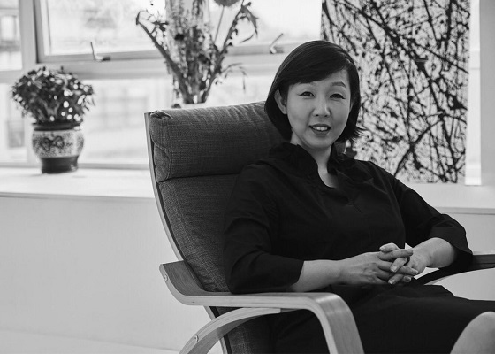

> *LEAFF aims to champion the growing collaboration in East Asian filmmaking with a philosophy that marks a shift in the cinematic landscape of East Asia, and moves away from cultural and cinematic borders. Our vision is to bring a much wider, eclectic, and diverse programme of films from over 10 countries to show the richness and diversity of the region and its people. We want to draw people in with the familiar, and offer opportunities to see something new.*

This paper analyses the data collected from the London East Asia Film Festival (LEAFF) 2018. It does so with the intention of providing a summary of how successful the event was, and to provide a benchmark for future editions

# Section 1: Key Performance Metrics

This section presents key analyis of the festival’s performance data.

## Section 1.1: How much did the audience enjoy LEAFF 2018?

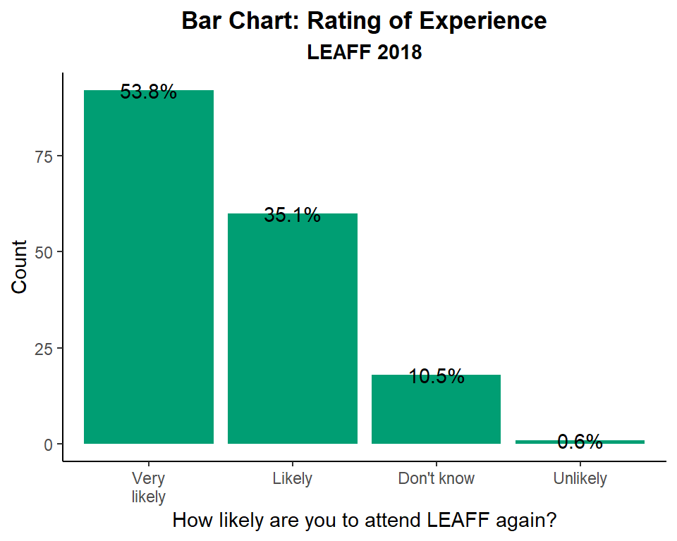

Figure 1

- In **Figure 1**, 89% of attendees rated their LEAFF 2018 experience as being so good that they are either **Very likely** or **Likely** to attend the festival again in the future.
- This demonstrates that the majority of attendees enjoyed LEAFF 2018 and that the programme and activities which were part of this were successful in capturing the public’s interests and appetite for film and cinema.

## Section 1.2: How likely are the audience to recommend LEAFF to friends and colleagues?

- In the table below, 99% of respondents said they were either **Very likely** or **Likely** to recommend a friend or colleague to attend LEAFF.
- This reinforces the findings made in *Section 1.1* where 89% of respondents said they were **Very likely** or **Likely** to attend future LEAFFs.

*Likelihood of audience recommending LEAFF to friends or colleagues*

| Choice | Total | Percent |
| --- | --- | --- |
| Very likely | 92 | 56% |
| Likely | 70 | 43% |
| Unlikely | 1 | 1% |
| NA | 0 | 0% |

## Section 1.3: How many do screenings does our audience see?

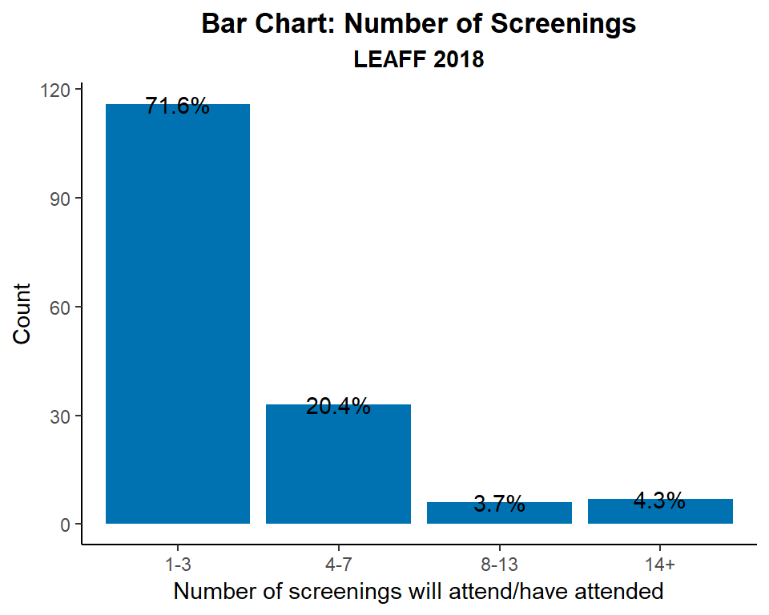

Figure 2

## Section 1.4: Why does our audience come to LEAFF?

- Digging further into why 89% of survey respondents enjoyed their LEAFF experience such that they are **Very likely** or **Likely** to attend, we see the top three reasons for why they wanted to attend LEAFF were *The film (40%), The director(s) and/or actor(s) (16%) and The subject/theme (15%)*.
- This demonstrates that LEAFF is more than just a festival that screens films, but it also caters for film fans’ other interests.

## Section 1.5: How many previous and new audiences came to LEAFF 2018?

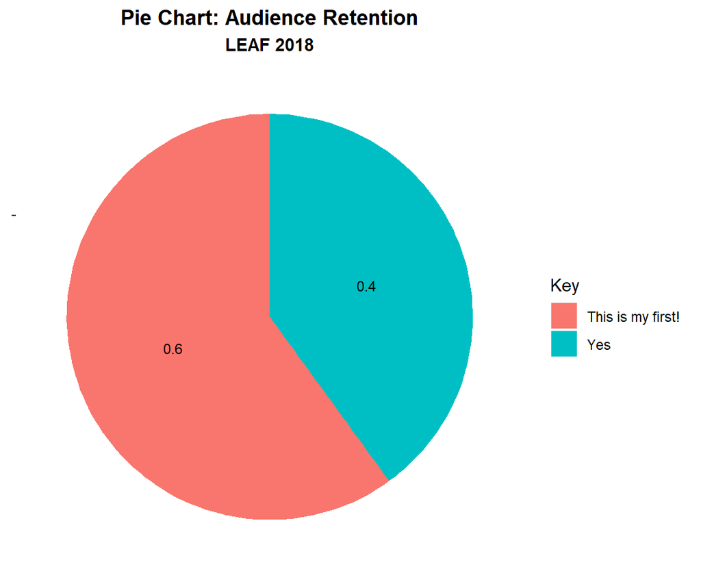

Figure 3

- In **Figure 3**, we have 60% of respondents saying this is their first time coming to the festival.
- Of the remaining 40% of respondents who have returned from previous festivals, we have the following breakdown:
  - Yes - 2015 (18%)
  - Yes - 2016 (29%)
  - Yes - 2017 (52%)
- As a sizeable proportion of attendees have returned to LEAFF from previous years, then this demonstrates that previous LEAFFs were effective in encouraging people to return for this year’s festival.

# Concluding Remarks

[figure not shown]

- From the data analysed in this report, the key findings are:

**Survey respondents enjoyed LEAFF 2018 so much that 89% of them will return for future editions of LEAFF.**

**Survey respondents enjoyed LEAFF 2018 so much that 99% of them will recommend a friend or colleague to attend LEAFF.**

**The top three reasons for why survey respondents wanted to attend LEAFF were *The film (40%), The director(s) and/or actor(s) (16%) and The subject/theme (15%)*.**

**60% of survey respondents said this is their first time coming to the festival, showing that LEAFF was effective in attracting new audience memebers and retaining previous members.**